© Bản quyền thuộc về Quantopian Inc.  
© Bản quyền sửa đổi thuộc về AI Cafe¹  
Giấy phép [Creative Commons Attribution 4.0](https://creativecommons.org/licenses/by/4.0/legalcode).  
[Khuyến cáo](https://aicafe.one/khuyen-cao/)

# Kiểm định giả thuyết thống kê

by Maxwell Margenot and Delaney Granizo-Mackenzie. Reviewed by Gilbert Wasserman.

Edited by AI Cafe¹

Suy diễn thống kê, thực hành đưa ra dự đoán về một nhóm lớn dựa trên các mẫu nhỏ hơn, thường được chia thành hai phần, **ước lượng** và **kiểm định giả thuyết**. Ước lượng cung cấp giá trị cho những điều cụ thể mà bạn có thể quan tâm, chẳng hạn như trung bình hoặc phương sai, với một khoảng tin cậy được cung cấp. Một khoảng tin cậy cung cấp một vùng mà trong đó bạn có thể mong đợi tìm thấy giá trị thực của tham số mà bạn đã ước lượng, vì một ước lượng gần như không bao giờ chính xác. Các khoảng tin cậy sử dụng một mức độ tin cậy đã được xác định để chọn độ rộng của khoảng, để đạt được độ tin cậy cao hơn, chúng ta phải báo cáo một khoảng rộng hơn. Để biết thêm thông tin, vui lòng xem bài giảng về Khoảng Tin Cậy.

Ví dụ, chúng ta có thể ước lượng một giá trị trung bình mẫu là $100$, với một khoảng tin cậy từ $90$ đến $110$ ở mức độ tin cậy $95\%$. Điều này không có nghĩa là giá trị trung bình của quần thể thực sự nằm giữa $90$ và $110$ với xác suất $95\%$, vì giá trị trung bình thực sự là một giá trị cố định và xác suất là $100\%$ hoặc $0\%$, nhưng chúng ta không biết giá trị nào. Thay vào đó, ý nghĩa của điều này là qua nhiều lần tính toán khoảng tin cậy $95\%$ với giả định rằng các giả định cơ bản về phân phối vẫn đúng, giá trị trung bình của quần thể sẽ nằm trong khoảng $95\%$ tổng số lần.

Điều này cho chúng ta một ý tưởng về các đặc điểm cụ thể mà một quần thể tổng thể có thể thể hiện, dựa trên một mẫu. Kiểm định giả thuyết cung cấp một trọng tâm khác, chi tiết một khung cho việc kiểm tra thống kê các giá trị giả thuyết. Bằng cách đưa ra một khẳng định về giá trị mà một giá trị nên có, bạn tạo ra một giả thuyết có thể kiểm tra.

Một điều cần nhớ là các bài kiểm tra thống kê được thiết kế sao cho nếu tất cả các điều kiện tiên quyết đều đúng, bạn nên nhận được câu trả lời đúng về dữ liệu một tỷ lệ phần trăm nhất định của tổng số lần. Khi bạn chấp nhận một giả thuyết là đúng dựa trên một bài kiểm tra, điều đó không có nghĩa là nó chắc chắn đúng. Nó chỉ có nghĩa là bạn có thể biết xác suất bạn sai.

## Giả thuyết Null và Giả thuyết Thay thế

Điều đầu tiên chúng ta cần giới thiệu là giả thuyết null, thường được viết là $H_0$. Giả thuyết null là trường hợp mặc định, thường phản ánh nhận thức chung hiện tại về thế giới. Giả thuyết thay thế là giả thuyết mà bạn đang kiểm tra.

### Ví dụ

Giả thuyết thay thế $H_A$ là bạn sở hữu hơn 10 đôi giày. Giả thuyết null $H_0$ là bạn không sở hữu hơn 10 đôi giày.

Giả thuyết thay thế $H_A$ là việc ăn pizza có liên quan đến béo phì. Giả thuyết null $H_0$ là không có mối liên quan.

Giả thuyết thay thế $H_A$ là lợi nhuận trung bình của FPT > 0. Giả thuyết null $H_0$ là lợi nhuận trung bình <= 0.

### Độ khó trong việc kiểm tra

Một số giả thuyết dễ kiểm tra hơn những giả thuyết khác. Ví dụ, giả thuyết thay thế, "Tôi sở hữu hơn 10 đôi giày." và giả thuyết null đi kèm rằng bạn không sở hữu, dễ dàng được kiểm tra bằng cách đếm số đôi giày bạn có. Tuy nhiên, bạn vẫn có thể không nhận được câu trả lời hoàn hảo mọi lúc trong trường hợp này, vì có thể có sai sót trong việc đo lường khi đếm, mặc dù khá nhỏ.

Mặt khác, giả thuyết "Số lượng các loài côn trùng lớn hơn số lượng các vì sao trong vũ trụ" sẽ khó kiểm tra hơn và yêu cầu thu thập nhiều dữ liệu.

### Giả thuyết phải có thể kiểm tra

Một giả thuyết không thể mơ hồ, nếu không thì làm thế nào để kiểm tra nó? Ví dụ, "Giao dịch theo xu hướng là một cách tốt để kiếm tiền" thực sự không thể kiểm tra. 'Tốt' có nghĩa là gì? Chúng ta đang thảo luận về loại giao dịch theo xu hướng nào? Các giả thuyết nên rất cụ thể và loại kiểm tra cần thiết nên theo ngay từ giả thuyết.

## Cách Thực Hiện Kiểm Định Giả Thuyết

Các bước chính trong kiểm định giả thuyết như sau:

1. Đưa ra giả thuyết và giả thuyết thay thế.
2. Xác định thống kê kiểm định phù hợp và phân phối của nó. Đảm bảo rằng tất cả các giả định về dữ liệu đều được đáp ứng (tính dừng, tính chuẩn, v.v.).
3. Xác định mức ý nghĩa, $\alpha$.
4. Từ $\alpha$ và phân phối, tính toán 'giá trị tới hạn'.
5. Thu thập dữ liệu và tính toán thống kê kiểm định.
6. So sánh thống kê kiểm định với giá trị tới hạn và quyết định chấp nhận hay bác bỏ giả thuyết.

Đầu tiên, chúng ta đưa ra giả thuyết mà chúng ta muốn kiểm tra. Chúng ta làm điều này bằng cách xác định một **giả thuyết null** và một **giả thuyết thay thế**. Giả thuyết null, $H_0$, là giả thuyết mà chúng ta muốn kiểm tra, trong khi giả thuyết thay thế, $H_A$, là giả thuyết được chấp nhận trong trường hợp $H_0$ bị bác bỏ.

Giả sử rằng chúng ta muốn kiểm tra xem lợi nhuận trung bình của cổ phiếu FPT có dương hay không. Tham số mà chúng ta đang kiểm tra được ký hiệu là $\theta$ và giá trị đề xuất của tham số được ký hiệu là $\theta_0$, trong trường hợp này bằng $0$. Vậy chúng ta nói rằng $H_0$ của chúng ta là $\theta = \theta_0$, rằng lợi nhuận là âm, và $H_A$ của chúng ta là $\theta \neq \theta_0$. Bao gồm cấu trúc này, có ba cách có thể để hình thành giả thuyết null và giả thuyết thay thế:

1. $H_0: \theta = \theta_0$ so với $H_A: \theta \neq \theta_0$ (Giả thuyết thay thế "không bằng")
2. $H_0: \theta \leq \theta_0$ so với $H_A: \theta > \theta_0$ (Giả thuyết thay thế "lớn hơn")
3. $H_0: \theta \geq \theta_0$ so với $H_A: \theta < \theta_0$ (Giả thuyết thay thế "nhỏ hơn")

Trong trường hợp này, khi chúng ta đang kiểm tra lợi nhuận của FPT, $\theta = \mu_{FPT}$, đại diện cho lợi nhuận trung bình của cổ phiếu. Vì chúng ta đang kiểm tra xem lợi nhuận có dương hay âm, chúng ta có rằng $\theta_0 = 0$. Ví dụ của chúng ta theo cấu trúc đầu tiên của một bài kiểm tra giả thuyết. Đây là một **kiểm định giả thuyết hai phía** (hoặc **kiểm định giả thuyết hai đuôi**). Cấu trúc thứ hai và thứ ba là ví dụ về **kiểm định giả thuyết một phía** (hoặc **kiểm định giả thuyết một đuôi**). Với một kiểm định một phía, chúng ta bác bỏ giả thuyết null để ủng hộ giả thuyết thay thế chỉ khi dữ liệu cho thấy rằng $\theta$ lớn hơn hoặc nhỏ hơn $\theta_0$. Một kiểm định hai phía bác bỏ giả thuyết null để ủng hộ giả thuyết thay thế nếu dữ liệu cho thấy rằng $\theta$ lớn hơn hoặc nhỏ hơn $\theta_0$.

Vậy nếu chúng ta viết giả thuyết của mình cho FPT bằng những thuật ngữ định tính hơn, chúng ta sẽ có:

\begin{eqnarray} H_0 &:& \text{Lợi nhuận trung bình trên cổ phiếu FPT là $0$}\\ H_A &:& \text{Lợi nhuận trung bình trên cổ phiếu FPT không phải là $0$} \end{eqnarray}

Khi hình thành một bài kiểm định giả thuyết, giả thuyết null và giả thuyết thay thế phải bổ sung cho nhau. Giữa chúng phải bao trùm tất cả các giá trị của $\theta$. Bất kể loại kiểm định giả thuyết nào mà chúng ta đang thực hiện, chúng ta luôn kiểm tra giả thuyết null như thể $\theta = \theta_0$. Trong trường hợp của bất kỳ kiểm định một phía nào, điều này vẫn sẽ cung cấp đủ bằng chứng cho chúng ta để đưa ra quyết định. Ví dụ, nếu $H_0: \theta \leq 0$, $H_A: \theta > 0$, và chúng ta có đủ bằng chứng để bác bỏ $H_0: \theta = 0$ để ủng hộ $H_A: \theta > 0$, thì điều này cũng đúng cho tất cả các giá trị nhỏ hơn $0$.

Loại kiểm định giả thuyết phổ biến nhất là kiểm định hai phía, "không bằng", vì nó thể hiện một quan điểm trung lập. Các kiểm định giả thuyết một phía ít trung lập hơn so với kiểm định "không bằng", phản ánh suy nghĩ của người kiểm tra. Các kiểm định một phía thường được sử dụng để kiểm tra các kết quả "mong muốn" hoặc các kết quả mà người kiểm tra có ý tưởng trước đó.

```python
import numpy as np
import matplotlib.pyplot as plt
```

```python
# Cài thư viện lấy dữ liệu miễn phí
!curl -fsSLO https://raw.githubusercontent.com/algo-stocks/data/master/data.py
```

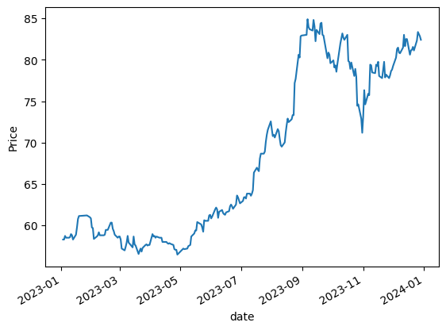

```python
from data import get_prices

start = '2023-01-01'
end = '2024-01-01'

prices = get_prices('FPT', start_date=start, end_date=end).dropna()

fpt_prices = prices.FPT

# plot prices
ax = fpt_prices.plot()
ax.set_ylabel('Price');
```

Tính lợi nhuận (returns)

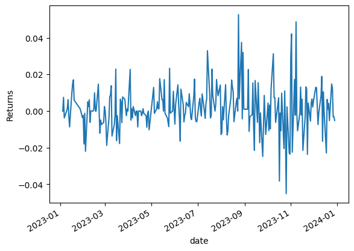

```python
# transform it into returns
fpt_returns = fpt_prices.pct_change()[1:]

ax = fpt_returns.plot()
ax.set_ylabel('Returns');
```

## Tại sao tất cả những điều này là cần thiết?

Tại sao chúng ta không chỉ cần lấy trung bình lợi nhuận của FPT và kiểm tra xem chúng có > 0 không? Bởi vì chúng ta không thể nhìn vào quá trình tạo ra dữ liệu thực tế phía sau lợi nhuận, chúng ta chỉ có thể lấy mẫu lợi nhuận trong một khoảng thời gian hạn chế nào đó. Bởi vì chúng ta chỉ quan sát một mẫu, mẫu đó có thể phản ánh đúng hoặc không đúng trạng thái thực sự của quá trình cơ bản. Chính vì sự không chắc chắn này mà chúng ta cần sử dụng các bài kiểm tra thống kê.

Tiếp theo, chúng ta xác định **thống kê kiểm định** thích hợp và phân phối xác suất của nó. Một thống kê kiểm định thường có dạng như sau:

$$ \text{Thống kê kiểm định} = \frac{\text{Thống kê mẫu} - \text{Giá trị của tham số tổng thể dưới $H_0$ ($\theta_0$)}}{\text{Sai số chuẩn của thống kê mẫu}} $$

Thống kê kiểm định được tính toán dựa trên dữ liệu mẫu và được so sánh với phân phối xác suất của nó để xác định xem có nên bác bỏ giả thuyết không hay không bác bỏ giả thuyết null. Vì chúng ta đang kiểm tra lợi suất trung bình trên cổ phiếu FPT, chúng ta có thể sử dụng giá trị trung bình mẫu, $\bar{X}_\mu$, làm thống kê mẫu của chúng ta. Chúng ta tính sai số chuẩn của giá trị trung bình mẫu là $\sigma_{\bar{X}} = \frac{\sigma}{\sqrt{n}}$ nếu chúng ta biết độ lệch chuẩn, $\sigma$, hoặc là $s_{\bar{X}} = \frac{s}{\sqrt{n}}$, trong đó $s$ là độ lệch chuẩn mẫu. Vậy nên, sử dụng những định nghĩa này, thống kê kiểm định của chúng ta có thể được tính như sau:

$$ \frac{\bar{X}_\mu - \theta_0}{s_{\bar{X}}} = \frac{\bar{X}_\mu - 0}{s/\sqrt{n}} $$

Bốn phân phối phổ biến nhất cho thống kê kiểm định như sau:

- Phân phối $t$ ($t$-test)
- Phân phối chuẩn ($z$-test)
- Phân phối chi-bình phương ($\chi^2$) ($\chi^2$-test)
- Phân phối $F$ ($F$-test)

Chúng ta sẽ đề cập đến chúng một cách chi tiết sau. Hiện tại, chúng ta có thể nói rằng chúng ta có thể sử dụng một bài kiểm tra $z$ với các giả định của chúng ta trong ví dụ FPT.

Sau khi xác định thống kê kiểm định phù hợp và phân phối xác suất, chúng ta cần xác định **mức ý nghĩa** của bài kiểm tra, ký hiệu là $\alpha$. Các giá trị mà chúng ta so sánh thống kê kiểm định của mình để bác bỏ hoặc không bác bỏ $H_0$ được xác định dựa trên giá trị $\alpha$ của chúng ta.

|  | Tình huống Thực tế |  |
| --- | --- | --- |
| **Quyết định** | $H_0$ Đúng | $H_0$ Sai |
| Không bác bỏ $H_0$ | Quyết định Đúng | Lỗi Loại II |
| Bác bỏ $H_0$ (chấp nhận $H_A$) | Lỗi Loại I | Quyết định Đúng |

Mức ý nghĩa của chúng ta bằng với xác suất xảy ra lỗi loại I (một "dương tính giả"). Xác suất xảy ra lỗi loại II (một "âm tính giả") được ký hiệu là $\beta$. Nếu chúng ta cố gắng giảm xác suất xảy ra lỗi loại I, chúng ta sẽ tăng xác suất xảy ra lỗi loại II, dẫn đến một sự đánh đổi. Cách duy nhất để giảm xác suất của cả lỗi loại I và lỗi loại II xảy ra là tăng kích thước mẫu.

Các mức ý nghĩa thông thường là $0.1$, $0.05$, và $0.01$. Bác bỏ giả thuyết null tại $0.1$ có nghĩa là chúng ta có một số bằng chứng cho thấy giả thuyết null là sai, $0.05$ có nghĩa là chúng ta có bằng chứng mạnh cho thấy giả thuyết null là sai, bác bỏ tại $0.01$ chúng ta có bằng chứng rất mạnh cho thấy giả thuyết null là sai.

### Giá trị tới hạn (Critical Value)

Bây giờ chúng ta sẽ xác định giá trị tới hạn, hay còn gọi là điểm từ chối. Giá trị tới hạn cho thống kê kiểm tra của chúng ta là giá trị mà chúng ta so sánh với thống kê kiểm tra khi quyết định xem có nên từ chối giả thuyết null. Nếu chúng ta từ chối giả thuyết null, chúng ta nói rằng kết quả là **có ý nghĩa thống kê**, trong khi nếu chúng ta không từ chối giả thuyết null, chúng ta nói rằng kết quả là **không có ý nghĩa thống kê**.

Chúng ta so sánh thống kê kiểm tra của mình với một **giá trị tới hạn** để quyết định xem có từ chối hay không từ chối giả thuyết null. Giá trị tới hạn của một bài kiểm tra được xác định dựa trên $\alpha$ của kiểm tra giả thuyết của chúng ta cũng như phân phối đã chọn. Trong trường hợp của chúng ta, giả sử $\alpha = 0.05$, vì vậy mức ý nghĩa của chúng ta là $0.05$. Với kiểm tra $z$ một phía, có hai cách khác nhau để xem xét các giá trị tới hạn:

- Nếu chúng ta kiểm tra $H_0$: $\theta \leq \theta_0$, $H_A$: $\theta > \theta_0$ tại $\alpha = 0.05$, giá trị tới hạn của chúng ta là $z_{0.05} = 1.645$. Vì vậy, chúng ta so sánh thống kê kiểm tra của mình và chúng ta từ chối giả thuyết null nếu $z > 1.645$.
- Nếu chúng ta kiểm tra $H_0$: $\theta \geq \theta_0$, $H_A$: $\theta < \theta_0$ tại $\alpha = 0.05$, giá trị tới hạn của chúng ta là $-z_{0.05} = -1.645$. Do đó, chúng ta so sánh thống kê kiểm tra của mình và chúng ta từ chối giả thuyết không nếu $z < -1.645$.

Một bài kiểm tra hai phía là một tình huống hơi khác. Vì nó là hai phía, có hai điểm từ chối, âm và dương. $\alpha$ của chúng ta là $0.05$, vì vậy tổng xác suất của lỗi loại I phải cộng lại thành $0.05$. Do đó, chúng ta chia $0.05$ thành hai phần để các điểm từ chối của chúng ta là $z_{0.025}$ và $-z_{0.025}$ cho các giá trị tới hạn dương và âm, tương ứng. Đối với một bài kiểm tra $z$, các giá trị này là $1.96$ và $-1.96$. Do đó, chúng ta từ chối giả thuyết null nếu $z < -1.96$ hoặc nếu $z > 1.96$. Nếu chúng ta thấy rằng $-1.96 \leq z \leq 1.96$, chúng ta không từ chối giả thuyết null.

Khi tiến hành một bài kiểm tra giả thuyết, bạn cũng có thể sử dụng một **giá trị $p$** để xác định kết quả. Giá trị $p$ là mức độ ý nghĩa tối thiểu mà bạn có thể từ chối giả thuyết null. Thường thì mọi người sẽ diễn giải giá trị $p$ là "xác suất mà giả thuyết null sai", nhưng điều này là gây hiểu lầm. Giá trị $p$ chỉ có ý nghĩa khi được so sánh với giá trị ý nghĩa. Nếu giá trị $p$ nhỏ hơn $\alpha$, chúng ta từ chối giả thuyết null và ngược lại. Giá trị $p$ thấp hơn không làm cho một thứ gì đó "có ý nghĩa thống kê hơn". Rất nhiều đầu ra thống kê sẽ tính toán giá trị $p$ cho bạn, nhưng cũng có thể tính toán nó một cách thủ công. Việc tính toán phụ thuộc vào loại bài kiểm tra giả thuyết của bạn và CDF (được đề cập trong bài giảng về Biến ngẫu nhiên) của phân phối mà bạn đang làm việc. Để tính toán giá trị $p$ một cách thủ công, hãy làm như sau:

- Trong một bài kiểm tra giả thuyết 'nhỏ hơn hoặc bằng', giá trị $p$ là $1 - CDF(\text{Thống kê kiểm tra})$
- Trong một bài kiểm tra giả thuyết 'lớn hơn hoặc bằng', giá trị $p$ là $CDF(\text{Thống kê kiểm tra})$
- Trong một bài kiểm tra giả thuyết 'không bằng', giá trị $p$ là $2 * 1 - CDF(|\text{Thống kê kiểm tra}|)$

Các giá trị ý nghĩa kết nối rất tốt với các khoảng tin cậy, điều này được đề cập sâu hơn trong bài giảng về Khoảng tin cậy của chúng ta. Một khoảng tin cậy cung cấp cho chúng ta một ước lượng về phạm vi giá trị có thể của một tham số dựa trên một mức độ ý nghĩa nhất định. Ví dụ, nếu khoảng tin cậy $99\%$ của chúng ta cho trung bình của lợi nhuận FPT là $(-0.0020, 0.0023)$, điều đó có nghĩa là có $99\%$ khả năng rằng giá trị thực sự của trung bình nằm trong khoảng đó.

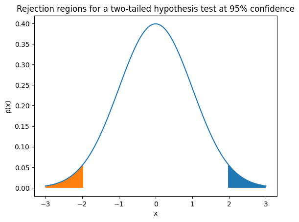

```python
# Plot a standard normal distribution and mark the critical regions with shading
x = np.linspace(-3, 3, 100)
norm_pdf = lambda x: (1/np.sqrt(2 * np.pi)) * np.exp(-x * x / 2)
y = norm_pdf(x)

fig, ax = plt.subplots(1, 1, sharex=True)
ax.plot(x, y)
ax.fill_between(x, 0, y, where = x > 1.96)
ax.fill_between(x, 0, y, where = x < -1.96)
plt.title('Rejection regions for a two-tailed hypothesis test at 95% confidence')
plt.xlabel('x')
plt.ylabel('p(x)');
```

Bây giờ chúng ta sẽ thu thập dữ liệu liên quan cho bài kiểm tra của mình và tính toán thống kê kiểm tra cho một bài kiểm tra hai phía với mức ý nghĩa $5\%$. Hãy nhớ rằng bất kỳ đặc điểm tiêu cực nào của dữ liệu sẽ ảnh hưởng xấu đến bài kiểm tra giả thuyết của chúng ta và có thể làm cho nó trở nên không hợp lệ. Trong trường hợp bài kiểm tra lợi nhuận của FPT, chúng ta có thể gặp phải vấn đề thiên lệch theo thời gian, hoặc thiên lệch nhìn trước (nếu chúng ta chuẩn bị bài kiểm tra không đúng cách). Như thường lệ với dữ liệu lịch sử, dữ liệu mà chúng ta làm việc có thể dẫn đến một kết quả kiểm tra cụ thể mà có thể không còn đúng trong tương lai. Chúng ta cũng phải đảm bảo rằng dữ liệu không bao gồm bất kỳ giá trị nào mà chúng ta không biết trong khoảng thời gian mà chúng ta đang kiểm tra (mặc dù điều này thường là vấn đề hơn khi so sánh nhiều thứ với các bài kiểm tra giả thuyết).

Ở đây chúng ta sẽ tính toán thống kê kiểm tra:

```python
n = len(fpt_returns)
test_statistic = ((fpt_returns.mean() - 0) /
                (fpt_returns.std()/np.sqrt(n)))
print('t test statistic: ', test_statistic)
```

```
t test statistic:  1.8766844055861165
```

Để đưa ra quyết định thống kê cho bài kiểm tra, chúng ta so sánh thống kê kiểm tra của mình với giá trị tới hạn. Thống kê kiểm tra của chúng ta như đã nêu ở trên nằm giữa hai giá trị tới hạn (−1.96, 1.96) cho một bài kiểm tra $z$ hai đuôi với mức tin cậy 95%, vì vậy trong ví dụ này chúng ta **không bác bỏ** giả thuyết $H_0$ của mình, giả thuyết rằng lợi nhuận của FPT bằng $0$.

Nếu chúng ta chọn xác định kết quả của bài kiểm tra giả thuyết này bằng cách sử dụng giá trị $p$, chúng ta sẽ tính giá trị $p$ theo cách sau:

```python
from scipy.stats import t

p_val = 2 * (1 - t.cdf(test_statistic, n - 1))
print('P-value is: ', p_val)
```

```
P-value is:  0.06174030644962958
```

Bởi vì giá trị $p$-value lớn hơn mức ý nghĩa của chúng ta, $\alpha = 0.05$, chúng ta không bác bỏ giả thuyết null.

Sau khi chúng ta đưa ra quyết định thống kê, chúng ta cần chuyển nó thành thực tế. Thường thì điều này có thể khó khăn để thực hiện trực tiếp, nhưng kết quả có thể có những ý nghĩa khác. Trong trường hợp ví dụ của chúng ta, chúng ta đã phát hiện rằng lợi nhuận hàng ngày của FPT trong năm 2023 không khác biệt đáng kể so với $0$.

## Kiểm định giả thuyết về Trung bình

Phân phối $z$, hay phân phối chuẩn, là một phân phối xác suất quan trọng trong tài chính. Chúng ta thích khi mọi thứ được phân phối theo quy luật chuẩn vì điều này mang lại nhiều tính chất hữu ích. Hơn nữa, nhiều phương pháp cơ bản yêu cầu một giả định về tính chuẩn để tiến hành. Tuy nhiên, trong hầu hết các trường hợp, phân phối $z$ sẽ không phù hợp với dữ liệu của chúng ta. Chúng ta hiếm khi biết được giá trị tham số thực (trung bình và phương sai) của dữ liệu và phải dựa vào các xấp xỉ. Trong những trường hợp này, chúng ta nên sử dụng phân phối $t$, một xấp xỉ của phân phối chuẩn. Phân phối $t$ linh hoạt hơn khi nói đến kích thước mẫu nhỏ và được thiết kế để sử dụng với trung bình và phương sai mẫu. Nó có đuôi dày hơn và đỉnh thấp hơn, mang lại nhiều sự linh hoạt hơn so với phân phối chuẩn.

Cả phân phối $t$ và $z$ đều dựa vào một giả định cơ bản về tính chuẩn, điều này thường đúng khi chúng ta phân tích dữ liệu tài chính. Do đó, ngoài việc kiểm tra các trung bình riêng lẻ, việc so sánh giữa hai hoặc nhiều giá trị trung bình là hợp lý. Chúng ta có thể sử dụng một kiểm định giả thuyết để xác định xem các trung bình của một số tập dữ liệu có khác biệt về mặt thống kê hay không. Ở đây, chúng ta sẽ sử dụng phân phối $t$ để minh họa. Chúng ta sẽ so sánh lợi nhuận trung bình của chỉ số VNINDEX và cổ phiếu FPT bằng một kiểm định giả thuyết để xem liệu sự khác biệt có được coi là có ý nghĩa thống kê hay không.

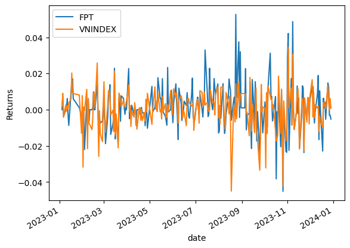

```python
start = '2023-01-01'
end = '2024-01-01'

closes = get_prices('FPT', 'VNINDEX', start_date=start, end_date=end).dropna()

fpt_vnindex_returns = closes.pct_change()[1:]
fpt_vnindex_returns.plot()
plt.ylabel('Returns');
```

Trong khi những lợi suất này có vẻ có cùng một giá trị trung bình, chúng ta vẫn không có đủ bằng chứng để khẳng định điều đó. Chúng ta sử dụng một bài kiểm tra giả thuyết để củng cố nghi ngờ của mình trên cơ sở thống kê.

Khi so sánh hai giá trị trung bình, các bài kiểm tra giả thuyết của chúng ta được nêu như sau:

1. $H_0: \mu_1 - \mu_2 = \theta_0, \ H_A: \mu_1 - \mu_2 \neq \theta_0$
2. $H_0: \mu_1 - \mu_2 \leq \theta_0, \ H_A: \mu_1 - \mu_2 > \theta_0$
3. $H_0: \mu_1 - \mu_2 \geq \theta_0, \ H_A: \mu_1 - \mu_2 < \theta_0$

Trong đó $\mu_1, \mu_2$ là các giá trị trung bình tương ứng của VNINDEX và FPT và $\theta_0$ là tham số mà chúng ta đang kiểm tra. Chúng ta sẽ sử dụng bài kiểm tra giả thuyết đầu tiên để kiểm tra sự bình đẳng của hai lợi suất. Nếu chúng ta giả định rằng phương sai của tổng thể là như nhau, thì thống kê kiểm tra của chúng ta được tính như sau:

$$ t = \frac{(\bar{X}_1 - \bar{X}_2) - (\mu_1 - \mu_2)}{(\frac{s_p^2}{n_1} + \frac{s_p^2}{n_2})^{1/2}} = \frac{\bar{X}_1 - \bar{X}_2}{(\frac{s_p^2}{n_1} + \frac{s_p^2}{n_2})^{1/2}} $$

Với $s_p^2 = \frac{(n_1 - 1)s_1^2 + (n_2 - 1)s_2^2)}{n_1 + n_2 - 2}$ là ước lượng của phương sai chung, được gọi là phương sai gộp, và $n_1 + n_2 - 2$ là số bậc tự do ($n_1 - 1$ và $n_2 - 1$ cho mỗi tập dữ liệu). Một bài kiểm tra $t$-test thông thường về một giá trị trung bình giả định rằng tất cả các phương sai liên quan là như nhau với các phân phối chuẩn cơ bản. Nếu chúng ta giả định rằng các phương sai không bằng nhau, chúng ta phải tính toán thống kê kiểm tra của mình theo cách khác. Thống kê kiểm tra trong trường hợp này là:

$$ t = \frac{(\bar{X}_1 - \bar{X}_2) - (\mu_1 - \mu_2)}{(\frac{s_1^2}{n_1} + \frac{s_2^2}{n_2})^{1/2}} = \frac{\bar{X}_1 - \bar{X}_2}{(\frac{s_1^2}{n_1} + \frac{s_2^2}{n_2})^{1/2}} $$

Trong đó số bậc tự do được sử dụng để tìm thống kê quan trọng là bậc tự do đã được sửa đổi, tức là số giá trị có thể thay đổi, $df = \frac{(\frac{s_1^2}{n_1} + \frac{s_2^2}{n_2})^2}{\frac{(s_1^2/n_1)^2}{n_1} + \frac{(s_2^2/n_2)^2}{n_2}}$. Điều này bảo tồn tính chuẩn cơ bản của dữ liệu đang được kiểm tra trong khi tính đến sự khác biệt về phương sai. Tính toán thống kê theo cách này loại bỏ nhiều vấn đề có thể xảy ra nếu chúng ta có các phương sai không bằng nhau, đặc biệt là nếu kích thước mẫu của dữ liệu cơ bản cũng khác nhau. Trường hợp cụ thể này của bài kiểm tra $t$ được gọi là "Bài kiểm tra $t$ của Welch với phương sai không bằng nhau".

Trong ví dụ này, chúng ta giả định rằng phương sai của lợi suất VNINDEX và FPT là khác nhau. Chúng ta nghĩ rằng FPT sẽ có rủi ro cao hơn VNINDEX nên chúng ta sẽ sử dụng công thức thứ hai của thống kê kiểm tra. Giả sử rằng $\alpha = 0.05$ vì vậy chúng ta đang tính toán một bài kiểm tra giả thuyết 95%.

```python
# Sample mean values
mu_vnindex = fpt_vnindex_returns['VNINDEX'].mean()
mu_fpt = fpt_vnindex_returns['FPT'].mean()
s_vnindex = fpt_vnindex_returns['VNINDEX'].std()
s_fpt = fpt_vnindex_returns['FPT'].std()
n_vnindex = len(fpt_vnindex_returns['VNINDEX'])
n_fpt = len(fpt_vnindex_returns['FPT'])

test_statistic = ((mu_vnindex - mu_fpt) - 0)/((s_vnindex**2/n_vnindex) + (s_fpt**2/n_fpt))**0.5
df = ((s_vnindex**2/n_vnindex) + (s_fpt**2/n_fpt))**2/(((s_vnindex**2 / n_vnindex)**2 /n_vnindex)+((s_fpt**2 / n_fpt)**2/n_fpt))

print('t test statistic: ', test_statistic)
print('Degrees of freedom (modified):', df)
```

```
t test statistic:  -1.0679435283415197
Degrees of freedom (modified): 483.02035390343275
```

Khi xem xét [bảng phân phối t](https://en.wikipedia.org/wiki/Student%27s_t-distribution#Table_of_selected_values), chúng ta xác định rằng các giá trị quan trọng cho bài kiểm tra giả thuyết hai phía của chúng ta là $-1.96$ và $1.96$. Thống kê kiểm tra của chúng ta nằm giữa các giá trị này, vì vậy chúng ta **không bác bỏ** giả thuyết null và xác định rằng sự khác biệt giữa lợi nhuận của VNINDEX và FPT là **không** khác biệt đáng kể so với $0$.

## Kiểm định Giả thuyết về Độ Phân Tán

Nếu chúng ta muốn kiểm tra độ phân tán của các quần thể, chúng ta cần sử dụng một phân phối khác với phân phối $t$ và $z$. Độ phân tán phải theo định nghĩa lớn hơn (hoặc bằng) $0$ và thực tế là các phân phối mà chúng ta đã làm việc cho đến nay cho phép các giá trị âm khiến chúng không khả thi như các phân phối kiểm tra. Rủi ro được định lượng theo độ lệch chuẩn và độ phân tán, vì vậy phương pháp kiểm định giả thuyết này là một bổ sung hữu ích cho bộ công cụ tài chính của chúng ta.

Thay vì các phân phối $t$ và $z$, chúng ta sẽ làm việc với các phân phối $\chi^2$ cho các bài kiểm tra độ phân tán đơn và các phân phối $F$ cho việc so sánh độ phân tán. Những phân phối này có giới hạn dưới là $0$, làm cho chúng khả thi cho việc kiểm tra theo cách này.

Cũng giống như với tất cả các bài kiểm tra giả thuyết khác của chúng ta, các bài kiểm tra độ phân tán đơn có thể có ba dạng:

1. $H_0: \sigma^2 = \sigma_0^2, \ H_A: \sigma^2 \neq \sigma_0^2$
2. $H_0: \sigma^2 \leq \sigma_0^2, \ H_A: \sigma^2 > \sigma_0^2$
3. $H_0: \sigma^2 \geq \sigma_0^2, \ H_A: \sigma^2 < \sigma_0^2$

Phân phối $\chi^2$ là một họ các hàm với mỗi công thức khác nhau được xác định bởi số bậc tự do. Hình dạng của phân phối khác nhau cho mỗi giá trị khác nhau của số bậc tự do, $k$.

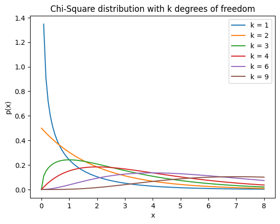

```python
from scipy.stats import chi2

# Here we show what a chi-square looks like
x = np.linspace(0, 8, 100)
y_1 = chi2.pdf(x, 1)
y_2 = chi2.pdf(x, 2)
y_3 = chi2.pdf(x, 3)
y_4 = chi2.pdf(x, 4)
y_6 = chi2.pdf(x, 6)
y_9 = chi2.pdf(x, 9)

fig, ax = plt.subplots()
ax.plot(x, y_1, label = 'k = 1')
ax.plot(x, y_2, label = 'k = 2')
ax.plot(x, y_3, label = 'k = 3')
ax.plot(x, y_4, label = 'k = 4')
ax.plot(x, y_6, label = 'k = 6')
ax.plot(x, y_9, label = 'k = 9')
ax.legend()
plt.title('Chi-Square distribution with k degrees of freedom')
plt.xlabel('x')
plt.ylabel('p(x)');
```

Chúng ta tính toán thống kê kiểm định $\chi^2$ như sau:

$$ \chi^2 = \frac{(n - 1)s^2}{\sigma_0^2} $$

Trong đó, $s^2$ là phương sai mẫu và $n$ là kích thước của tập dữ liệu. Số bậc tự do là $n - 1$ và điều này được sử dụng cùng với thống kê kiểm định để xác định giá trị ngưỡng của kiểm định giả thuyết $\chi^2$ của chúng ta.

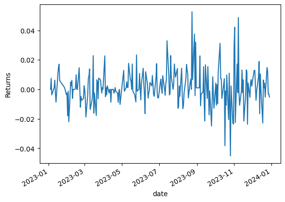

```python
fpt_returns.plot()
plt.ylabel('Returns');
```

Bây giờ chúng ta sẽ sử dụng kiểm định $\chi^2$ để kiểm tra giá trị phương sai của cổ phiếu FPT. Giả sử rằng chúng ta muốn sử dụng $\alpha = 0.01$ để kiểm tra xem phương sai của FPT có nhỏ hơn hoặc bằng $0.0001$ (tức là độ lệch chuẩn, hay rủi ro, nhỏ hơn hoặc bằng $0.01$).

$$ H_0: \sigma^2 \leq 0.0001, \ H_A: \sigma^2 > 0.0001 $$

Bây giờ chúng ta sẽ tính toán thống kê kiểm định:

```python
test_statistic = (len(fpt_returns) - 1) * fpt_returns.std()**2 / 0.0001
print('Chi-square test statistic:', test_statistic)
```

```
Chi-square test statistic: 377.7369882781435
```

```python
# Here we calculate the critical value directly because our df is too high for most chisquare tables
crit_value = chi2.ppf(0.99, len(fpt_returns) - 1)
print('Critical value at a = 0.01 with', len(fpt_returns), 'df:', crit_value)
```

```
Critical value at a = 0.01 with 248 df: 301.6263657123845
```

Bởi vì chúng ta đang sử dụng công thức "nhỏ hơn hoặc bằng" trong một bài kiểm tra giả thuyết một phía, chúng ta bác bỏ giả thuyết null nếu thống kê kiểm tra của chúng ta lớn hơn giá trị tới hạn. Vì $377.7 > 301.6$, chúng ta **bác bỏ** giả thuyết null ủng hộ giả thuyết thay thế và khẳng định rằng $\sigma^2 > 0.0001$.

### So sánh Hai Phương Sai

Chúng ta có thể so sánh phương sai của hai biến khác nhau bằng cách sử dụng phân phối $F$. Khi xây dựng một so sánh phương sai bằng cách sử dụng kiểm định $F$, các giả thuyết được thiết lập như sau:

1. $H_0: \sigma_1^2 = \sigma_2^2, \ H_A: \sigma_1^2 \neq \sigma_2^2$
2. $H_0: \sigma_1^2 \leq \sigma_2^2, \ H_A: \sigma_1^2 > \sigma_2^2$
3. $H_0: \sigma_1^2 \geq \sigma_2^2, \ H_A: \sigma_1^2 < \sigma_2^2$

Phân phối $F$ tương tự như phân phối $\chi^2$ ở chỗ nó không đối xứng và bị giới hạn dưới bởi $0$. Phân phối $F$ được xác định với hai giá trị bậc tự do khác nhau. Đối với mục đích kiểm định giả thuyết, mỗi bậc tự do tương ứng với một trong các yếu tố mà chúng ta đang so sánh. Một biến ngẫu nhiên $F$ có thể được xây dựng từ hai phân phối $\chi^2$ khác nhau. $X$ là một biến ngẫu nhiên $F$ nếu nó có thể được viết dưới dạng $X = \frac{Y_1/d_1}{Y_2/d_2}$, trong đó $Y_1$ và $Y_2$ là các biến ngẫu nhiên $\chi^2$ với bậc tự do lần lượt là $d_1$ và $d_2$.

Biến ngẫu nhiên $F$ thực chất là tỷ lệ của các phương sai. Do đó, việc xây dựng thống kê kiểm định $F$ được thực hiện bằng cách lấy tỷ lệ của các phương sai mẫu của dữ liệu mà chúng ta muốn kiểm tra. Chúng ta có thể đơn giản chọn $\sigma_1^2$ và $\sigma_2^2$ để đại diện cho một trong các phương sai mà chúng ta đang so sánh, để cho thống kê $F$ của chúng ta lớn hơn $1$.

$$ F = \frac{s_1^2}{s_2^2} $$

Hãy so sánh VNINDEX và FPT để xem liệu phương sai của chúng có giống nhau không (một kiểm định giả thuyết 'không bằng'). Chúng ta sẽ sử dụng mức ý nghĩa $\alpha = 0.05$. Nhớ rằng đối với một kiểm định hai phía, chúng ta tính toán các giá trị tới hạn dưới và trên bằng cách sử dụng các giá trị của $\alpha/2$. Chúng ta thu thập dữ liệu và tính toán thống kê kiểm định.

```python
# FPT and VNINDEX variances from above
vnindex_std_dev = fpt_vnindex_returns['VNINDEX'].std()
fpt_std_dev = fpt_vnindex_returns['FPT'].std()
print('VNINDEX standard deviation is:', vnindex_std_dev)
print('FPT standard deviation is:', fpt_std_dev)
```

```
VNINDEX standard deviation is: 0.010481074501275348
FPT standard deviation is: 0.012366485142047403
```

Lưu ý rằng độ lệch chuẩn của FPT lớn hơn độ lệch chuẩn của VNINDEX. Do đó, chúng ta chọn $\sigma_1^2$ để biểu thị phương sai của FPT và $\sigma_2^2$ để biểu thị phương sai của VNINDEX.

```python
test_statistic = (fpt_std_dev / vnindex_std_dev)**2
print("F Test statistic:", test_statistic)
```

```
F Test statistic: 1.3921336911930091
```

```python
# Since these values are taken over the same time period, they will have the same number of degrees of freedom
df1 = len(fpt_vnindex_returns['FPT']) - 1
df2 = len(fpt_vnindex_returns['VNINDEX']) - 1

print('Degrees of freedom for VNINDEX:', df2)
print('Degrees of freedom for FPT:', df1)
```

```
Degrees of freedom for VNINDEX: 247
Degrees of freedom for FPT: 247
```

```python
from scipy.stats import f

upper_crit_value = f.ppf(0.975, df1, df2)
lower_crit_value = f.ppf(0.025, df1, df2)
print('Upper critical value at a = 0.05 with df1 = {0} and df2 = {1}:'.format(df1, df2), upper_crit_value)
print('Lower critical value at a = 0.05 with df1 = {0} and df2 = {1}:'.format(df1, df2), lower_crit_value)
```

```
Upper critical value at a = 0.05 with df1 = 247 and df2 = 247: 1.2840198376575698
Lower critical value at a = 0.05 with df1 = 247 and df2 = 247: 0.7788041669389583
```

Chúng ta thấy rằng giá trị F-statistic của chúng ta lớn hơn giá trị tới hạn trên cho bài kiểm tra F của chúng ta. Do đó, chúng ta **bác bỏ** giả thuyết null để ủng hộ giả thuyết thay thế và kết luận rằng phương sai của FPT và VNINDEX thực sự khác nhau.

## Tham khảo

- "Quantitative Investment Analysis", by DeFusco, McLeavey, Pinto, and Runkle.

*Lưu ý: Tài liệu này mang tính chất chia sẻ kiến thức khoa học dữ liệu. Các mã chứng khoán xuất hiện trong tài liệu chỉ mang tính chất minh hoạ, không khuyến nghị đầu tư. Chúng tôi không chịu trách nhiệm trước mọi rủi ro nào do sử dụng tài liệu này.*